# Notes: Bioconductor for Genomic Data Science

### GRanges Usage

#### The capital DataFrame

We get an IRanges that’s **a single column** so we can do the standard subsetting and use the dollar `$` operator as we are used to, and still get the expanded IRanges object.

```r
df = DataFrame(ir = ir1, score = rnorm(3))
df
```

```
## DataFrame with 3 rows and 2 columns
##           ir     score
##    <IRanges> <numeric>
## A1         1  0.991825
## A2         4 -0.469194
## A3         5  0.274172
```

```r
df[1,1]
```

```
## IRanges object with 1 range and 0 metadata columns:
##          start       end     width
##      <integer> <integer> <integer>
##   A1         1         1         1
```

```r
df$ir
```

```
## IRanges object with 3 ranges and 0 metadata columns:
##          start       end     width
##      <integer> <integer> <integer>
##   A1         1         1         1
##   A2         4         4         1
##   A3         5         5         1
```

The classic `data.frame` (lowercase), on the other hand, still returns *three different columns for IRanges* and doesn’t rlly keep things together.

```r
classic_df = data.frame(ir = ir1, score = rnorm(3))
classic_df
```

```
##   ir.start ir.end ir.width ir.names      score
## 1        1      1        1       A1  0.3627453
## 2        4      4        1       A2 -1.0662663
## 3        5      5        1       A3 -0.3714182
```

#### GRanges metadata columns

Additional columns to the GRanges object. We can set the ‘score’ metadata by `values(GRanges)` and add a DataFrame.

```r
values(gr) = DataFrame(score = rnorm(4))
gr
```

```
## GRanges object with 4 ranges and 1 metadata column:
##       seqnames    ranges strand |     score
##          <Rle> <IRanges>  <Rle> | <numeric>
##   [1]     chr1       1-3      + |  1.317432
##   [2]     chr2       1-3      - |  0.429204
##   [3]     chr1       5-7      + |  2.793774
##   [4]     chr2       3-5      * |  0.478792
##   -------
##   seqinfo: 2 sequences from hg19 genome
```

```r
mcols(gr)
```

```
## DataFrame with 4 rows and 1 column
##       score
##   <numeric>
## 1  1.317432
## 2  0.429204
## 3  2.793774
## 4  0.478792
```

```r
# We (arbitrarily) set a new metadata column
gr$score2 <- gr$score / 20
gr
```

```
## GRanges object with 4 ranges and 2 metadata columns:
##       seqnames    ranges strand |     score    score2
##          <Rle> <IRanges>  <Rle> | <numeric> <numeric>
##   [1]     chr1       1-3      + |  1.317432 0.0658716
##   [2]     chr2       1-3      - |  0.429204 0.0214602
##   [3]     chr1       5-7      + |  2.793774 0.1396887
##   [4]     chr2       3-5      * |  0.478792 0.0239396
##   -------
##   seqinfo: 2 sequences from hg19 genome
```

#### findOverlaps()

Pretty similar to IRanges, tho these are **strand-specific**!! Or add `ignore.strand = TRUE`.

```r
gr3 = GRanges(seqnames = c("chr1"), strand = c("*","*","-","+"), ranges = IRanges(start = c(1,2,3,4), width = 3))
gr
```

```
## GRanges object with 4 ranges and 2 metadata columns:
##       seqnames    ranges strand |     score    score2
##          <Rle> <IRanges>  <Rle> | <numeric> <numeric>
##   [1]     chr1       1-3      + |  1.317432 0.0658716
##   [2]     chr2       1-3      - |  0.429204 0.0214602
##   [3]     chr1       5-7      + |  2.793774 0.1396887
##   [4]     chr2       3-5      * |  0.478792 0.0239396
##   -------
##   seqinfo: 2 sequences from hg19 genome
```

```r
gr3
```

```
## GRanges object with 4 ranges and 0 metadata columns:
##       seqnames    ranges strand
##          <Rle> <IRanges>  <Rle>
##   [1]     chr1       1-3      *
##   [2]     chr1       2-4      *
##   [3]     chr1       3-5      -
##   [4]     chr1       4-6      +
##   -------
##   seqinfo: 1 sequence from an unspecified genome; no seqlengths
```

```r
findOverlaps(gr, gr3)
```

```
## Hits object with 3 hits and 0 metadata columns:
##       queryHits subjectHits
##       <integer>   <integer>
##   [1]         1           1
##   [2]         1           2
##   [3]         3           4
##   -------
##   queryLength: 4 / subjectLength: 4
```

```r
findOverlaps(gr, gr3, ignore.strand = TRUE) # This allows intervals on the positive strand to have overlaps with those on the negative strand.
```

```
## Hits object with 5 hits and 0 metadata columns:
##       queryHits subjectHits
##       <integer>   <integer>
##   [1]         1           1
##   [2]         1           2
##   [3]         1           3
##   [4]         3           3
##   [5]         3           4
##   -------
##   queryLength: 4 / subjectLength: 4
```

```r
subsetByOverlaps(gr, gr3)
```

```
## GRanges object with 2 ranges and 2 metadata columns:
##       seqnames    ranges strand |     score    score2
##          <Rle> <IRanges>  <Rle> | <numeric> <numeric>
##   [1]     chr1       1-3      + |   1.31743 0.0658716
##   [2]     chr1       5-7      + |   2.79377 0.1396887
##   -------
##   seqinfo: 2 sequences from hg19 genome
```

```r
subsetByOverlaps(gr3, gr)
```

```
## GRanges object with 3 ranges and 0 metadata columns:
##       seqnames    ranges strand
##          <Rle> <IRanges>  <Rle>
##   [1]     chr1       1-3      *
##   [2]     chr1       2-4      *
##   [3]     chr1       4-6      +
##   -------
##   seqinfo: 1 sequence from an unspecified genome; no seqlengths
```

#### makeGRangesFromDataFrame()

If we have classic data.frames that look like GRanges.

```r
df2 = data.frame(chr = "chr1", start = 1:3, end = 4:6, score = rnorm(3))
makeGRangesFromDataFrame(df2) # Additional columns get dropped by default, but we can keep them using arguments.
```

```
## GRanges object with 3 ranges and 0 metadata columns:
##       seqnames    ranges strand
##          <Rle> <IRanges>  <Rle>
##   [1]     chr1       1-4      *
##   [2]     chr1       2-5      *
##   [3]     chr1       3-6      *
##   -------
##   seqinfo: 1 sequence from an unspecified genome; no seqlengths
```

```r
makeGRangesFromDataFrame(df2, keep.extra.columns = TRUE)
```

```
## GRanges object with 3 ranges and 1 metadata column:
##       seqnames    ranges strand |     score
##          <Rle> <IRanges>  <Rle> | <numeric>
##   [1]     chr1       1-4      * | -1.085861
##   [2]     chr1       2-5      * | -1.017846
##   [3]     chr1       3-6      * |  0.272757
##   -------
##   seqinfo: 1 sequence from an unspecified genome; no seqlengths
```

## AnnotationHub

AnnotationHub is a package that acts as an **interface** to online genomic resources. You create a hub (initialize the AnnotationHub object), which is a local database of large collections of publicly available genomic datasets. You can query this local database (which is actually like subsetting in vectors by `[]`) and you can retrieve the data you want by `[[]]`.

// Some of the following lines executed for too long so I annotated many of them

```r
library(AnnotationHub)
ah = AnnotationHub()
ah
```

```
## AnnotationHub with 70637 records
## # snapshotDate(): 2025-04-08
## # $dataprovider: Ensembl, BroadInstitute, UCSC, ftp://ftp.ncbi.nlm.nih.gov/g...
## # $species: Homo sapiens, Mus musculus, Drosophila melanogaster, Rattus norv...
## # $rdataclass: GRanges, TwoBitFile, BigWigFile, EnsDb, Rle, OrgDb, ChainFile...
## # additional mcols(): taxonomyid, genome, description,
## #   coordinate_1_based, maintainer, rdatadateadded, preparerclass, tags,
## #   rdatapath, sourceurl, sourcetype
## # retrieve records with, e.g., 'object[["AH5012"]]'
##
##              title
##   AH5012   | Chromosome Band
##   AH5013   | STS Markers
##   AH5014   | FISH Clones
##   AH5015   | Recomb Rate
##   AH5016   | ENCODE Pilot
##   ...        ...
##   AH121712 | Data.table for PubMed Author Information
##   AH121713 | Data.table for PMC
##   AH121714 | Data.table for MeSH (Descriptor)
##   AH121715 | Data.table for MeSH (Qualifier)
##   AH121716 | Data.table for MeSH (SCR)
```

```r
ah[1]
```

```
## AnnotationHub with 1 record
## # snapshotDate(): 2025-04-08
## # names(): AH5012
## # $dataprovider: UCSC
## # $species: Homo sapiens
## # $rdataclass: GRanges
## # $rdatadateadded: 2013-03-26
## # $title: Chromosome Band
## # $description: GRanges object from UCSC track 'Chromosome Band'
## # $taxonomyid: 9606
## # $genome: hg19
## # $sourcetype: UCSC track
## # $sourceurl: rtracklayer://hgdownload.cse.ucsc.edu/goldenpath/hg19/database...
## # $sourcesize: NA
## # $tags: c("cytoBand", "UCSC", "track", "Gene", "Transcript",
## #   "Annotation")
## # retrieve record with 'object[["AH5012"]]'
```

```r
# Since there's so much data we can narrow the scope down:
# ah2 = subset(ah, species == "Homo sapiens")

query(ah, pattern = "H3K4me3")
```

```
## AnnotationHub with 2028 records
## # snapshotDate(): 2025-04-08
## # $dataprovider: BroadInstitute, UCSC, Haemcode, ENCODE, NA
## # $species: Homo sapiens, Mus musculus
## # $rdataclass: GRanges, BigWigFile
## # additional mcols(): taxonomyid, genome, description,
## #   coordinate_1_based, maintainer, rdatadateadded, preparerclass, tags,
## #   rdatapath, sourceurl, sourcetype
## # retrieve records with, e.g., 'object[["AH23256"]]'
##
##              title
##   AH23256  | wgEncodeBroadHistoneGm12878H3k4me3StdPk.broadPeak.gz
##   AH23273  | wgEncodeBroadHistoneH1hescH3k4me3StdPk.broadPeak.gz
##   AH23297  | wgEncodeBroadHistoneHelas3H3k4me3StdPk.broadPeak.gz
##   AH23311  | wgEncodeBroadHistoneHepg2H3k4me3StdPk.broadPeak.gz
##   AH23324  | wgEncodeBroadHistoneHmecH3k4me3StdPk.broadPeak.gz
##   ...        ...
##   AH46851  | UW.Fetal_Thymus.H3K4me3.H-24644.Histone.DS21539.gappedPeak.gz
##   AH116723 | TENET_10_cancer_panel_promoter_regions
##   AH116727 | ENCODE_dELS_regions
##   AH116728 | ENCODE_pELS_regions
##   AH116729 | ENCODE_PLS_regions
```

```r
# Or even query by a specific cell line
q = query(ah, pattern = c("H3K4me3", "Gm12878"))
# The 'snapshotDate' actually matches the version of Bioconductor we are using

# Retrieving the GRanges object of interest
# genes = ah[["AH23324"]]

# display(ah) doesn't work... the function could not be found. deprecated i guess,,, so sad..
# This function is supposed to allow us to use AnnotationHub with a spreadsheet-like interface. We assign the return value to a new variable because we can then go to the spreadsheet-like interface and manually select the records to send them back into R.
#ah_selected = display(ah) # The spreadsheet-like interface opens up, and then we can search and select the records of interest...
```

The demo features querying and then retrieving data from AnnotationHub. After the genomic data of interest (namely, H3K4me3 peaks and RefSeq data (non-redundant!) in the human genome) is retrieved (**as GRanges objects**), we can use the functions learned above to carry out analysis (Fisher’s exact test) to see whether **trimethylation (H3K4me3) is enriched in promoter regions** (apply the `promoters()` function we illustrated earlier to extract the GRanges for only promoters from the entire RefSeq genomic data). Apply `findOverlaps`, `intersect`, etc.

// This is so very upsetting but for the first time after so long i felt like my cnbo memories for molecular biology got back T_T.

## Biostrings and BSgenome

### Basic intro to the two packages

**Biostrings**: a package that contains functionality for representing and manipulating biological strings and biodata.

- There’s also a DNAStringSet (like a list with each element being a DNAString), each DNAString doesn’t have to have the same width, but they have to only contain characters in the IUPAC code.

```r
library(Biostrings)
dna1 = DNAString("ACGT-G")
dna1[2:4]
```

```
## 3-letter DNAString object
## seq: CGT
```

```r
dna_set = DNAStringSet(c("ACG", "ACTGTGTG", "GTAC"))
dna_set
```

```
## DNAStringSet object of length 3:
##     width seq
## [1]     3 ACG
## [2]     8 ACTGTGTG
## [3]     4 GTAC
```

```r
IUPAC_CODE_MAP
```

```
##      A      C      G      T      M      R      W      S      Y      K      V
##    "A"    "C"    "G"    "T"   "AC"   "AG"   "AT"   "CG"   "CT"   "GT"  "ACG"
##      H      D      B      N
##  "ACT"  "AGT"  "CGT" "ACGT"
```

```r
dna_set[2] # Still a DNAStringSet object (like a list with length 1)
```

```
## DNAStringSet object of length 1:
##     width seq
## [1]     8 ACTGTGTG
```

```r
dna_set[[2]] # A DNAString object
```

```
## 8-letter DNAString object
## seq: ACTGTGTG
```

```r
names(dna_set) = paste0('seq',1:3)
sort(dna_set)
```

```
## DNAStringSet object of length 3:
##     width seq                                               names
## [1]     3 ACG                                               seq1
## [2]     8 ACTGTGTG                                          seq2
## [3]     4 GTAC                                              seq3
```

```r
# Reversion: this only means reverse in ordering; use the second function to find the sequence's reverse complement.
reverse(dna_set)
```

```
## DNAStringSet object of length 3:
##     width seq                                               names
## [1]     3 GCA                                               seq1
## [2]     8 GTGTGTCA                                          seq2
## [3]     4 CATG                                              seq3
```

```r
reverseComplement(dna_set)
```

```
## DNAStringSet object of length 3:
##     width seq                                               names
## [1]     3 CGT                                               seq1
## [2]     8 CACACAGT                                          seq2
## [3]     4 GTAC                                              seq3
```

```r
rev(dna1)
```

```
## 6-letter DNAString object
## seq: G-TGCA
```

```r
alphabetFrequency(dna_set)
```

```
##      A C G T M R W S Y K V H D B N - + .
## [1,] 1 1 1 0 0 0 0 0 0 0 0 0 0 0 0 0 0 0
## [2,] 1 1 3 3 0 0 0 0 0 0 0 0 0 0 0 0 0 0
## [3,] 1 1 1 1 0 0 0 0 0 0 0 0 0 0 0 0 0 0
```

```r
letterFrequency(dna_set, letters="GC") # default is OR (`|`)
```

```
##      G|C
## [1,]   2
## [2,]   4
## [3,]   2
```

```r
dinucleotideFrequency((dna_set))
```

```
##      AA AC AG AT CA CC CG CT GA GC GG GT TA TC TG TT
## [1,]  0  1  0  0  0  0  1  0  0  0  0  0  0  0  0  0
## [2,]  0  1  0  0  0  0  0  1  0  0  0  2  0  0  3  0
## [3,]  0  1  0  0  0  0  0  0  0  0  0  1  1  0  0  0
```

```r
# consensusMatrix: tells us how many elements/strings have a specific nucleotide of that position. See how it differed to alphabetFrequency()!
consensusMatrix(dna_set)
```

```
##   [,1] [,2] [,3] [,4] [,5] [,6] [,7] [,8]
## A    2    0    1    0    0    0    0    0
## C    0    2    0    1    0    0    0    0
## G    1    0    1    1    0    1    0    1
## T    0    1    1    0    1    0    1    0
## M    0    0    0    0    0    0    0    0
## R    0    0    0    0    0    0    0    0
## W    0    0    0    0    0    0    0    0
## S    0    0    0    0    0    0    0    0
## Y    0    0    0    0    0    0    0    0
## K    0    0    0    0    0    0    0    0
## V    0    0    0    0    0    0    0    0
## H    0    0    0    0    0    0    0    0
## D    0    0    0    0    0    0    0    0
## B    0    0    0    0    0    0    0    0
## N    0    0    0    0    0    0    0    0
## -    0    0    0    0    0    0    0    0
## +    0    0    0    0    0    0    0    0
## .    0    0    0    0    0    0    0    0
```

**BSgenome**: a package for dealing with and representing **full genomes**.

```r
library(BSgenome)
available.genomes() # Lists all the genomes that you can directly download from the Bioconductor website.
```

```
##   [1] "BSgenome.Alyrata.JGI.v1"
##   [2] "BSgenome.Amellifera.BeeBase.assembly4"
##   [3] "BSgenome.Amellifera.NCBI.AmelHAv3.1"
##   [4] "BSgenome.Amellifera.UCSC.apiMel2"
##   [5] "BSgenome.Amellifera.UCSC.apiMel2.masked"
##   [6] "BSgenome.Aofficinalis.NCBI.V1"
##   [7] "BSgenome.Athaliana.TAIR.04232008"
##   [8] "BSgenome.Athaliana.TAIR.TAIR9"
##   [9] "BSgenome.Btaurus.UCSC.bosTau3"
##  [10] "BSgenome.Btaurus.UCSC.bosTau3.masked"
##  [11] "BSgenome.Btaurus.UCSC.bosTau4"
##  [12] "BSgenome.Btaurus.UCSC.bosTau4.masked"
##  [13] "BSgenome.Btaurus.UCSC.bosTau6"
##  [14] "BSgenome.Btaurus.UCSC.bosTau6.masked"
##  [15] "BSgenome.Btaurus.UCSC.bosTau8"
```

[output cut: 98 more lines]

```r
library("BSgenome.Scerevisiae.UCSC.sacCer2") # Install the package first using BiocManager.
# When we load a genome package, we get a BSgenome object back that's the name of the species.
Scerevisiae
```

```
## | BSgenome object for Yeast
## | - organism: Saccharomyces cerevisiae
## | - provider: UCSC
## | - genome: sacCer2
## | - release date: June 2008
## | - 18 sequence(s):
## |     chrI    chrII   chrIII  chrIV   chrV    chrVI   chrVII  chrVIII chrIX
## |     chrX    chrXI   chrXII  chrXIII chrXIV  chrXV   chrXVI  chrM    2micron
## | Tips: call 'seqnames()' on the object to get all the sequence names, call
## | 'seqinfo()' to get the full sequence info, use the '$' or '[[' operator to
## | access a given sequence, see '?BSgenome' for more information.
```

```r
seqinfo(Scerevisiae)
```

```
## Seqinfo object with 18 sequences (2 circular) from sacCer2 genome:
##   seqnames seqlengths isCircular  genome
##   chrI         230208      FALSE sacCer2
##   chrII        813178      FALSE sacCer2
##   chrIII       316617      FALSE sacCer2
##   chrIV       1531919      FALSE sacCer2
##   chrV         576869      FALSE sacCer2
##   ...             ...        ...     ...
##   chrXIV       784333      FALSE sacCer2
##   chrXV       1091289      FALSE sacCer2
##   chrXVI       948062      FALSE sacCer2
##   chrM          85779       TRUE sacCer2
##   2micron        6318       TRUE sacCer2
```

```r
# Use the '$' or '[[]]' operator to access a given sequence (chromosome)
Scerevisiae$chrI # So this returns a DNAString object, to which we can apply the DNAString functions learned previously
```

```
## 230208-letter DNAString object
## seq: CCACACCACACCCACACACCCACACACCACACCACA...GGTGTGTGGGTGTGGTGTGGGTGTGGTGTGTGTGGG
```

```r
letterFrequency(Scerevisiae$chrI, "GC", as.prob = TRUE)
```

```
##       G|C
## 0.3927361
```

We might also want to calculate the GC content for every sequence (every DNAString object) in the full genome (the BSgenome object). We can do something similar to `lapply` using the function `bsapply`.

- `bsapply` is slightly different because behind the scenes when you run it, it’ll load and unload the different genomes as we need them.
- We start off by setting up a new BSParams object, which **contains the function we’re going to apply and the BSgenome object we’re going to apply it to**. Then we can just run `bsapply` on the BSParams object.

```r
param = new(Class = "BSParams", X = Scerevisiae, FUN = letterFrequency)
bsapply(param, "GC", as.prob = TRUE)
```

```
## $chrI
##       G|C
## 0.3927361
##
## $chrII
##       G|C
## 0.3834425
##
## $chrIII
##       G|C
## 0.3853173
##
## $chrIV
##       G|C
## 0.3790664
##
## $chrV
##       G|C
## 0.3850805
##
## $chrVI
##       G|C
## 0.3873284
##
## $chrVII
##       G|C
## 0.3806115
##
## $chrVIII
##       G|C
## 0.3849439
##
## $chrIX
##       G|C
## 0.3890153
##
## $chrX
##       G|C
## 0.3837346
##
```

[output cut: 16 more lines]

```
## $chrXV
##       G|C
## 0.3816065
##
## $chrXVI
##       G|C
## 0.3806407
##
## $chrM
##       G|C
## 0.1710908
##
## $`2micron`
##       G|C
## 0.3898386
```

```r
sum(unlist(bsapply(param, "GC"))) / sum(seqlengths(Scerevisiae))
```

```
## [1] 0.3814872
```

### Biostrings: matching

```r
# Matching a sequence against another sequence (matching two DNAString objects), returns a Views object
dna2 <- DNAString("ACGGGCAG")
matchPattern(pattern = dna2, subject = Scerevisiae$chrI)
```

```
## Views on a 230208-letter DNAString subject
## subject: CCACACCACACCCACACACCCACACACCACACCA...TGTGTGGGTGTGGTGTGGGTGTGGTGTGTGTGGG
## views:
##       start   end width
##   [1] 34484 34491     8 [ACGGGCAG]
##   [2] 62434 62441     8 [ACGGGCAG]
```

```r
countPattern(pattern = dna2, subject = Scerevisiae$chrI)
```

```
## [1] 2
```

```r
# Matching a sequence against a set of chromosomes/sequences, returns a GRanges object
vmatchPattern(pattern = dna2, Scerevisiae)
```

```
## GRanges object with 102 ranges and 0 metadata columns:
##         seqnames        ranges strand
##            <Rle>     <IRanges>  <Rle>
##     [1]     chrI   34484-34491      +
##     [2]     chrI   62434-62441      +
##     [3]     chrI   44674-44681      -
##     [4]     chrI 107279-107286      -
##     [5]    chrII 133492-133499      +
##     ...      ...           ...    ...
##    [98]   chrXVI 173651-173658      -
##    [99]   chrXVI 375045-375052      -
##   [100]   chrXVI 385410-385417      -
##   [101]   chrXVI 504270-504277      -
##   [102]   chrXVI 823355-823362      -
##   -------
##   seqinfo: 18 sequences (2 circular) from sacCer2 genome
```

**Other matching functions**:

- `matchPdict()` for finding all the matches of a set of patterns (‘dictionary’, built by taking in **a set of short reads** of the same length) in a reference sequence or set of reference sequences (the subject; the full genome).
- `matchPWM()` allows us to search the genome for eg. binding motifs for given transcription factors. PWM stands for position weight matrix, a probabilistic representation; using a PWM, any given sequence can be quantitatively scored against the motif model
- `pairwiseAlignment()` allows to map *millions of reads* against **a short sequence such as a gene**. It’s impossible to use global/local alignment when you map up against the entire genome, but very useful as long as you align them up to a very small section of the genome eg. just a gene.

`TrimLRPatterns()`: trims off specific patterns on the left and the right of a DNAStringSet

### The Views object

Pretty much like merging an IRanges (not a GRanges since no seqinfo) and a DNAStringSet object. **We can run the functions for a DNAStringSet on Views** eg. `alphabetFrequency()`, etc.

```r
vi <- matchPattern(pattern = dna2, subject = Scerevisiae$chrI)
vi
```

```
## Views on a 230208-letter DNAString subject
## subject: CCACACCACACCCACACACCCACACACCACACCA...TGTGTGGGTGTGGTGTGGGTGTGGTGTGTGTGGG
## views:
##       start   end width
##   [1] 34484 34491     8 [ACGGGCAG]
##   [2] 62434 62441     8 [ACGGGCAG]
```

```r
ranges(vi)
```

```
## IRanges object with 2 ranges and 0 metadata columns:
##           start       end     width
##       <integer> <integer> <integer>
##   [1]     34484     34491         8
##   [2]     62434     62441         8
```

```r
alphabetFrequency(vi)
```

```
##      A C G T M R W S Y K V H D B N - + .
## [1,] 2 2 4 0 0 0 0 0 0 0 0 0 0 0 0 0 0 0
## [2,] 2 2 4 0 0 0 0 0 0 0 0 0 0 0 0 0 0 0
```

Views are very powerful in representing short sequences **of a bigger object**. All we need to stall is coordinates rather than the actual sequence. So, a View basically consists of a a set of coordinates **plus an object they link onto**. This means we can do things like *shifting the View (on the bigger object)*.

```r
shift(vi, 10)
```

```
## Views on a 230208-letter DNAString subject
## subject: CCACACCACACCCACACACCCACACACCACACCA...TGTGTGGGTGTGGTGTGGGTGTGGTGTGTGTGGG
## views:
##       start   end width
##   [1] 34494 34501     8 [TCAACATT]
##   [2] 62444 62451     8 [TTGGTCGG]
```

```r
gr4 = vmatchPattern(pattern = dna2, Scerevisiae)
# We can create a Views like this: (remember? A Views is just like IRanges + DNAStringSet so we include the full genome (obtained as a BSgenome object; $each_chr is a DNAString) in the first argument to provide DNAString data)
gr4
```

```
## GRanges object with 102 ranges and 0 metadata columns:
##         seqnames        ranges strand
##            <Rle>     <IRanges>  <Rle>
##     [1]     chrI   34484-34491      +
##     [2]     chrI   62434-62441      +
##     [3]     chrI   44674-44681      -
##     [4]     chrI 107279-107286      -
##     [5]    chrII 133492-133499      +
##     ...      ...           ...    ...
##    [98]   chrXVI 173651-173658      -
##    [99]   chrXVI 375045-375052      -
##   [100]   chrXVI 385410-385417      -
##   [101]   chrXVI 504270-504277      -
##   [102]   chrXVI 823355-823362      -
##   -------
##   seqinfo: 18 sequences (2 circular) from sacCer2 genome
```

```r
vi2 = Views(Scerevisiae, gr4)
# Note the additional column for DNAStringSet
vi2
```

```
## BSgenomeViews object with 102 views and 0 metadata columns:
##         seqnames        ranges strand            dna
##            <Rle>     <IRanges>  <Rle> <DNAStringSet>
##     [1]     chrI   34484-34491      +     [ACGGGCAG]
##     [2]     chrI   62434-62441      +     [ACGGGCAG]
##     [3]     chrI   44674-44681      -     [ACGGGCAG]
##     [4]     chrI 107279-107286      -     [ACGGGCAG]
##     [5]    chrII 133492-133499      +     [ACGGGCAG]
##     ...      ...           ...    ...            ...
##    [98]   chrXVI 173651-173658      -     [ACGGGCAG]
##    [99]   chrXVI 375045-375052      -     [ACGGGCAG]
##   [100]   chrXVI 385410-385417      -     [ACGGGCAG]
##   [101]   chrXVI 504270-504277      -     [ACGGGCAG]
##   [102]   chrXVI 823355-823362      -     [ACGGGCAG]
##   -------
##   seqinfo: 18 sequences (2 circular) from sacCer2 genome
```

Recall that we’ve previously retrieved a GRanges object for H3g4me3 peaks in humans when learning AnnotationHub. Here we will use the same AnnotationHub object initialized earlier to query and retrieve the yeast *genes* (distinguish this GRanges from the ‘full genome’ BSgenome object!) and get their promoters, **and then use the DNAStringSet functions by leveraging the Views object**.

```r
query(ah, c("sacCer2", "genes"))
```

```
## AnnotationHub with 2 records
## # snapshotDate(): 2025-04-08
## # $dataprovider: UCSC
## # $species: Saccharomyces cerevisiae
## # $rdataclass: GRanges
## # additional mcols(): taxonomyid, genome, description,
## #   coordinate_1_based, maintainer, rdatadateadded, preparerclass, tags,
## #   rdatapath, sourceurl, sourcetype
## # retrieve records with, e.g., 'object[["AH7048"]]'
##
##            title
##   AH7048 | SGD Genes
##   AH7049 | Ensembl Genes
```

```r
yeast_genes = ah[["AH7048"]]
```

```
## loading from cache
```

```r
promoters = promoters(yeast_genes)
```

```
## Warning in valid.GenomicRanges.seqinfo(x, suggest.trim = TRUE): GRanges object contains 37 out-of-bound ranges located on sequences chrI,
##   chrV, chrX, chrII, chrIV, chrIX, chrVI, chrXI, chrXV, chrIII, chrVII, chrXII,
##   chrXIV, chrXVI, chrVIII, and chrXIII. Note that ranges located on a sequence
##   whose length is unknown (NA) or on a circular sequence are not considered
##   out-of-bound (use seqlengths() and isCircular() to get the lengths and
##   circularity flags of the underlying sequences). You can use trim() to trim
##   these ranges. See ?`trim,GenomicRanges-method` for more information.
```

We can view the ‘promoters’ GRanges to see why there’s this warning of ‘out-of-bound ranges’: many of the ranges are negative (invalid coordinates). In this case, we can just `trim` anything outside the sequence length of the genome.

```r
promoters
```

```
## GRanges object with 6717 ranges and 5 metadata columns:
##          seqnames        ranges strand |        name     score     itemRgb
##             <Rle>     <IRanges>  <Rle> | <character> <numeric> <character>
##      [1]     chrI 128802-131001      + |     YAL012W         0        <NA>
##      [2]     chrI     -1665-534      + |     YAL069W         0        <NA>
##      [3]     chrI     -1462-737      + |   YAL068W-A         0        <NA>
##      [4]     chrI     1970-4169      - |     YAL068C         0        <NA>
##      [5]     chrI      480-2679      + |   YAL067W-A         0        <NA>
##      ...      ...           ...    ... .         ...       ...         ...
##   [6713]  chrXIII 923601-925800      - |     YMR326C         0        <NA>
##   [6714]  2micron     -1748-451      + |      R0010W         0        <NA>
##   [6715]  2micron     2809-5008      - |      R0020C         0        <NA>
##   [6716]  2micron     1271-3470      + |      R0030W         0        <NA>
##   [6717]  2micron     5999-8198      - |      R0040C         0        <NA>
##                  thick        blocks
##              <IRanges> <IRangesList>
##      [1] 130802-131986        1-1185
##      [2]       335-649         1-315
##      [3]       538-792         1-255
##      [4]     1807-2169         1-363
##      [5]     2480-2707         1-228
##      ...           ...           ...
##   [6713] 923492-923800         1-309
##   [6714]      252-1523        1-1272
##   [6715]     1887-3008        1-1122
##   [6716]     3271-3816         1-546
##   [6717]     5308-6198         1-891
##   -------
##   seqinfo: 18 sequences (2 circular) from sacCer2 genome
```

```r
promoters = trim(promoters)
promViews = Views(Scerevisiae, promoters)
promViews
```

```
## BSgenomeViews object with 6717 views and 5 metadata columns:
##          seqnames        ranges strand                       dna |        name
##             <Rle>     <IRanges>  <Rle>            <DNAStringSet> | <character>
##      [1]     chrI 128802-131001      + [CGTATCAGGA...CAGTTGCCGC] |     YAL012W
##      [2]     chrI         1-534      + [CCACACCACA...CACTCACATC] |     YAL069W
##      [3]     chrI         1-737      + [CCACACCACA...CAGAAAAATC] |   YAL068W-A
##      [4]     chrI     1970-4169      - [TCTTACTTGC...TCGAAGTTGC] |     YAL068C
##      [5]     chrI      480-2679      + [CCACTTCACT...ACAACATTAA] |   YAL067W-A
##      ...      ...           ...    ...                       ... .         ...
##   [6713]  chrXIII 923601-924429      - [CCCCACACAC...AGAAAATTCA] |     YMR326C
##   [6714]  2micron     -1748-451      + [ATTATGAACG...TAAGCAATTC] |      R0010W
##   [6715]  2micron     2809-5008      - [TTTCGGAAGC...CGGTAATTGA] |      R0020C
##   [6716]  2micron     1271-3470      + [GACAACGTAT...TTCCGCTCAG] |      R0030W
##   [6717]  2micron     5999-8198      - [TAGGGATATA...GTAGGCCGTA] |      R0040C
##              score     itemRgb         thick        blocks
##          <numeric> <character>     <IRanges> <IRangesList>
##      [1]         0        <NA> 130802-131986        1-1185
##      [2]         0        <NA>       335-649         1-315
##      [3]         0        <NA>       538-792         1-255
##      [4]         0        <NA>     1807-2169         1-363
##      [5]         0        <NA>     2480-2707         1-228
##      ...       ...         ...           ...           ...
##   [6713]         0        <NA> 923492-923800         1-309
##   [6714]         0        <NA>      252-1523        1-1272
##   [6715]         0        <NA>     1887-3008        1-1122
##   [6716]         0        <NA>     3271-3816         1-546
##   [6717]         0        <NA>     5308-6198         1-891
##   -------
##   seqinfo: 18 sequences (2 circular) from sacCer2 genome
```

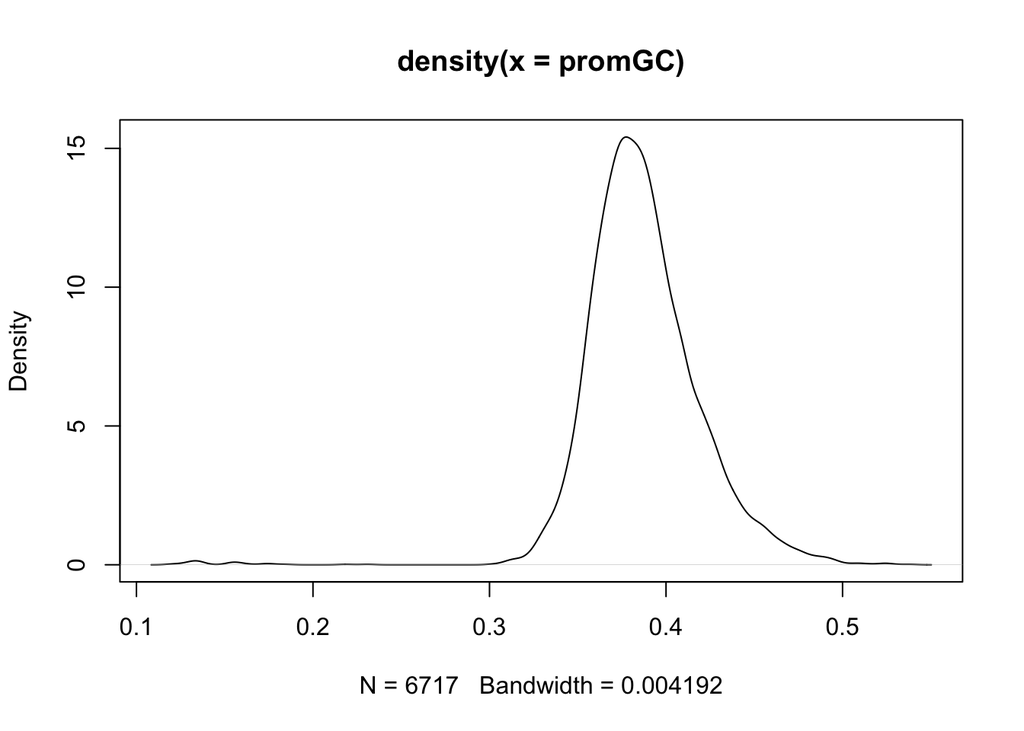

```r
# Then we use a DNAStringSet function to find the GC content specifically for promoter regions.
promGC = letterFrequency(promViews, "GC", as.prob = TRUE) # This will return probabilities for all of the 6717 ranges,,,, so we can visualize the overall GC content by plotting the density!!!
plot(density(promGC)) # The center is almost at 0.38, which is similar to our previously-calculated GC content for yeast's full genome.
```